# Statistical Inference - Course Project - Question 1

Francois Schonken

2014-09-21

## Synopsis

In this simulation, I will investigate the distribution of averages of 40 exponential(0.2)s. I will illustrate via simulation and associated explanatory text the properties of the distribution of the mean of 40 exponential(0.2)s in an attempt to address the following questions:

1. Show where the distribution is centered at and compare it to the theoretical center of the distribution.
2. Show how variable it is and compare it to the theoretical variance of the distribution.
3. Show that the distribution is approximately normal.
4. Evaluate the coverage of the confidence interval for $1/\lambda = \bar{X} \pm 1.96 \frac{S}{\sqrt{n}}$.

Initilize our simulation dataset with $\lambda$=0.2, 40 samples and 1000 rows per sample.

```r
lambda <- 0.2; s <- 40; n <- 1000;
dist <- matrix(rexp(s*n, rate=lambda), ncol=s, nrow=n)
distMean <- rowMeans(dist)
# summary(distMean)
```

### 1. Show where the distribution is centered at and compare it to the theoretical center of the distribution.

Calculate the expected theoretical center and the center (mean) of `distMean`.

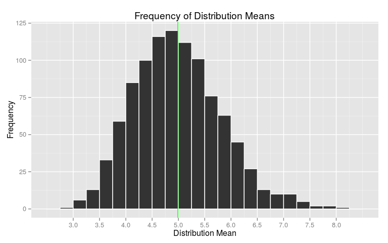

```r
centerTheoretical <- 1/lambda
centerCalculated <- mean(distMean)

pl <- ggplot(data=data.frame(distMean), aes(x=distMean)) +
  geom_histogram(binwidth=0.25, colour='white') +
  ggtitle('Frequency of Distribution Means') + xlab('Distribution Mean') +
  scale_x_continuous(breaks = round(seq(min(distMean), max(distMean), by = 0.5),1)) +
  geom_vline(xintercept=centerCalculated, colour='green') + ylab('Frequency')
print(plot)
```

The theoretical center of the distribution is: $1/\lambda$ = 1/0.2 = 5. The center of the distribution, indicated by the green line, is 4.972.